# DATA 606 Data Project Proposal

Congreesional Voting Records in the Age of Trump

Jeff Shamp

## Introduction

538 updates a daily tally of who in congress supports Pres. Trump by voting in alingment with his agend. The also have built a prediction as to how frequently the Congressperson ‘should’ vote in alignment with Pres. Trump based on how that congressperson’s district of state voted in the last general election. They also provide a simple difference between how there actual record differs from the predicted record.

I like this idea becuase it takes the general voting trend of a given district or state as a proxy for how aligned that location is with Pres. Trump’s agend. It makes for an interesting view into how well a member of Congress aligns with the voting record of their constituency vs. their alignment with Trump.

For my analysis, I will be focusing on the Senate and how the votes regarding Trump’s agenda and the 538 predicted agreement.

### Data Preparation

```r
library(RCurl)
library(ggplot2)
library(dplyr)
```

```r
d<-getURL("https://raw.githubusercontent.com/Shampjeff/cuny_msds/master/DATA_607/data/averages.csv")
df<-read.csv(text=d)
senate_df<-subset(df, chamber=='senate' & congress==0)
senate_df<- subset(senate_df, select=-c(district,bioguide, chamber, congress))
senate_df$party[senate_df$party == "I"]<- "Independent"
senate_df$party[senate_df$party == "D"]<- "Democrat"
senate_df$party[senate_df$party == "R"]<-"Republican"
head(senate_df)
```

```
##      last_name state      party votes agree_pct predicted_agree net_trump_vote
## 1418 Alexander    TN Republican   107 0.9065421       0.8663454     26.0057009
## 1421     Blunt    MO Republican   114 0.9298246       0.8061049     18.6371170
## 1424     Brown    OH   Democrat   114 0.2631579       0.6580150      8.1295744
## 1427      Burr    NC Republican   109 0.9174312       0.5725085      3.6552285
## 1430   Baldwin    WI   Democrat   114 0.2280702       0.5218532      0.7643432
## 1433   Boozman    AR Republican   115 0.9391304       0.8717218     26.9209780
```

## Research question

Does the predicted agree (with Trump) value generated by 538 differ significantly from the actual voting record?

### Cases

**What are the cases, and how many are there?**

```r
paste("There are ",dim(senate_df)[1], "cases")
```

```
## [1] "There are  115 cases"
```

Each case in this data set is the total number of votes each Senator casts for a bill. The `agree_pct` is the precent that each senator agrees with a bill that President Trump supports. `predicted_agree` is 538 estimate of how that Senator “should” vote in alignment with Trump has on their state’s voting record.

### Data collection

The data is collected by 538 from publicly available voting records of members of Congress. The agreement percents are based on which bills the President publicly supports.

### Type of study

This is an observational study.

### Data Source

The data is collected and stored by 538 and accessible through their website. The link can be found [here](https://projects.fivethirtyeight.com/congress-trump-score/).

### Dependent Variable

The predicted agreement with Trump is the dependent variable

### Independent Variable

The actual percent agreement with Trump is the independent variable.

### Relevant summary statistics

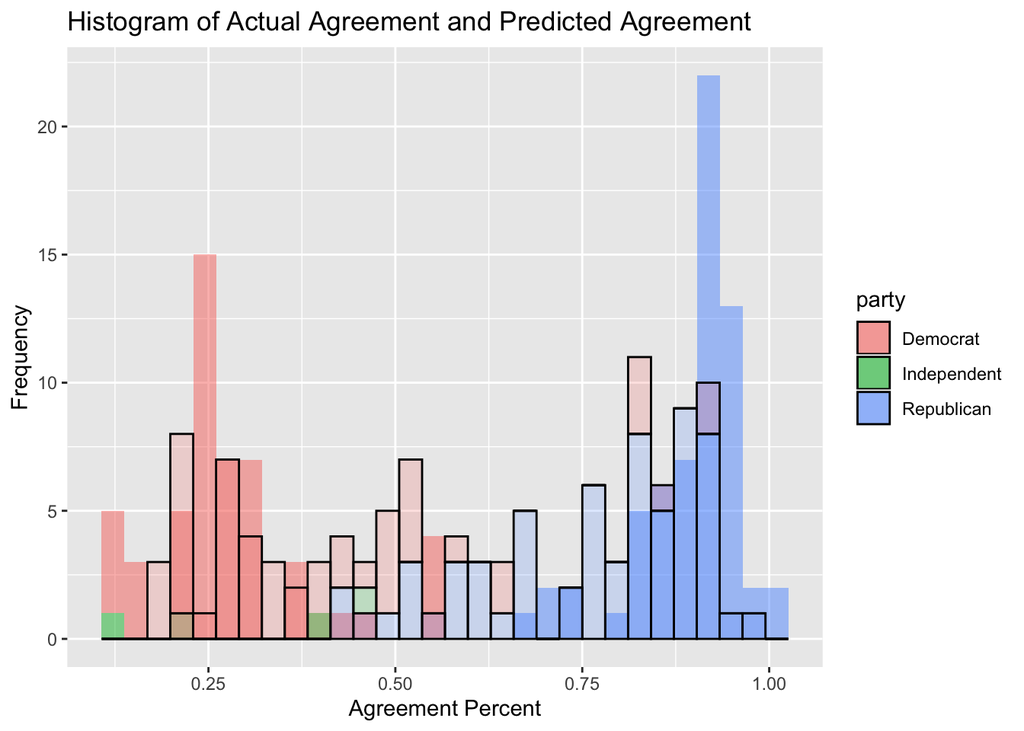

```r
senate_df %>%
  ggplot(aes(x=agree_pct, fill=party)) +
  geom_histogram(alpha=0.5)+
  geom_histogram(aes(x=predicted_agree, fill=party), alpha=0.2,color="black") +
  labs(x = "Agreement Percent", y="Frequency", title = "Histogram of Actual Agreement and Predicted Agreement")
```

Here we see that alignment with the president falls largely along party lines with some noticable outliers and confusion in the .40 - .65 agree percent range.

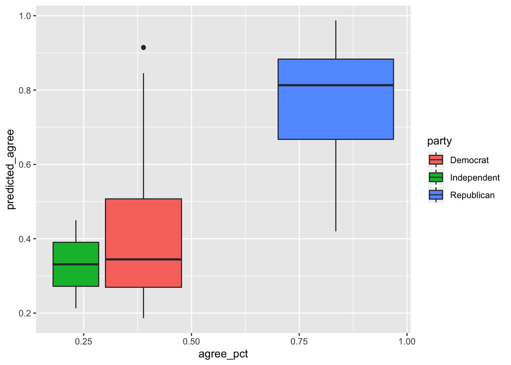

```r
senate_df %>%
  ggplot(aes(x=agree_pct, y=predicted_agree, fill=party)) +
  geom_boxplot()
```

```r
by(senate_df$agree_pct,senate_df$party,mean)
```

```
## senate_df$party: D
## [1] NA
## ------------------------------------------------------------
## senate_df$party: Democrat
## [1] 0.278745
## ------------------------------------------------------------
## senate_df$party: I
## [1] NA
## ------------------------------------------------------------
## senate_df$party: Independent
## [1] 0.2606522
## ------------------------------------------------------------
## senate_df$party: R
## [1] NA
## ------------------------------------------------------------
## senate_df$party: Republican
## [1] 0.8951126
```

```r
by(senate_df$predicted_agree,senate_df$party,mean)
```

```
## senate_df$party: D
## [1] NA
## ------------------------------------------------------------
## senate_df$party: Democrat
## [1] 0.4138634
## ------------------------------------------------------------
## senate_df$party: I
## [1] NA
## ------------------------------------------------------------
## senate_df$party: Independent
## [1] 0.3311976
## ------------------------------------------------------------
## senate_df$party: R
## [1] NA
## ------------------------------------------------------------
## senate_df$party: Republican
## [1] 0.7634981
```